# Inductive Bias for Seq2Seq Model

Inductive biases are quintessential for various model architecture, they can be used to add additional information to the model. In this post, we'll see how to update the formulation of Machine Translation's objective function with syntactic information during encoding or via multi-task learning. Additionally, we'll see how to inject these prior with templating for an image caption model[1].

## I. Introduction

There has been some work showing that syntactic information can be leveraged to improve translation quality in Neural Machine Translation models. This can be done on the source side directly during encoding or indirectly via multi-task learning to produce syntax-informed representations. There are challenges (i.e. additional complexity in inference when decoding over the latent states) regarding incorporating the syntax at the target side. To alleviate this issue existing approach leverages approximate inference over the latent states using a two-step decoding process. Ideally, in the first stage, a decoder produces a beam of latent states which leverage as conditions to feed into the second stage decoder to obtain the target word. In the aforementioned settings training and inference in these models can only use a limited sub-space of the latent states.

In this post, a new method leverages a new target-side syntax model that allows exhaustive exploration of the latent states to provide better translation quality. Similarly to existing work, this new method approximates the co-dependence between syntax and semantics of the target sentences by modeling the joint conditional probability of the target word and the syntactic information at each position. Compared to existing work, this method eliminates the sequential dependence between latent variables and simply infers the syntactic information at a given position based on the source text and the partial translation context. This approach gives this new method the possibility to search over a much larger set of latent states. With regards to the run time complexity, compared to existing methods it only introduces an additional term that is linear in the size of latent variable vocabulary and the length of the sentence.[1]

Its implementation uses a hybrid decoder that predicts two posterior distributions: the probability of syntactic choices at each position, and the probability of the word choices at each position conditioned on each of the possible values of the latent states. Given that the model cannot be trained directly by optimizing the data log-likelihood due to its non-convex property, A Neural Expectation Maximization method is devised, with an E-step that computes the posterior distribution of latent states under current model parameters, and an M-step that updates model parameters using gradient from back-propagation. By leveraging a supervision signal for the latent variable, the EM method can be modified to obtain a regularized training procedure. A parts-of-speech(POS) tag sequence was used to automatically generate an existing tagger as a source of supervision. Given that the decoder is exposed to a diverse set of latent states during the training procedure, it is more likely to generate diverse translation candidates. A decoding process for the most likely translations for different POS tag sequences is leveraged to obtain diverse sequences. This can be seen as an explicit and effective way of performing diverse translations than other methods based on re-ranking beam search or corse code planning[1].

## II. Machine Translation

We start with translation probability which is modeled using the probability of each target word y at time step n conditioned on the source sequence x and the partial target sequence:

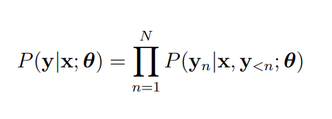

The joint conditional probability is given by :

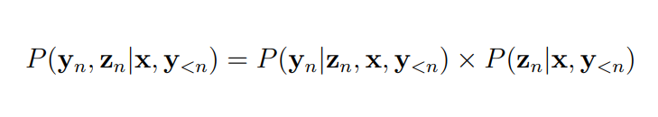

At Inference time we have :

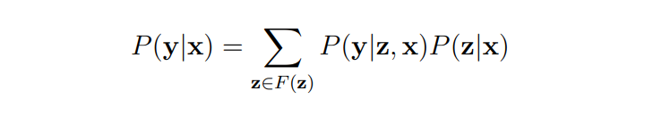

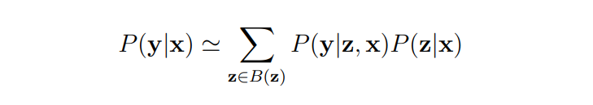

The posterior distribution for the transaltion probability can be obtained with:

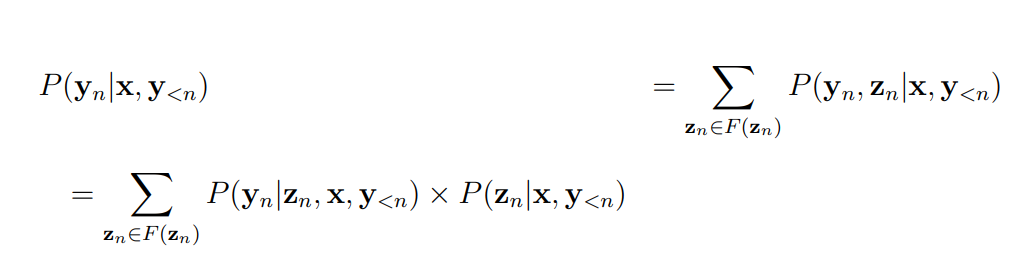

During training the objective function can be obtained with:

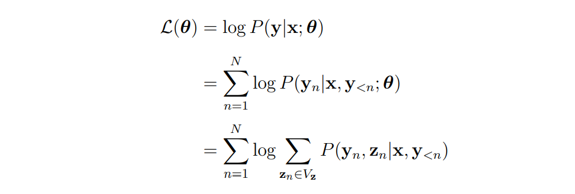

Using Jensen Inequality it can be re written as:

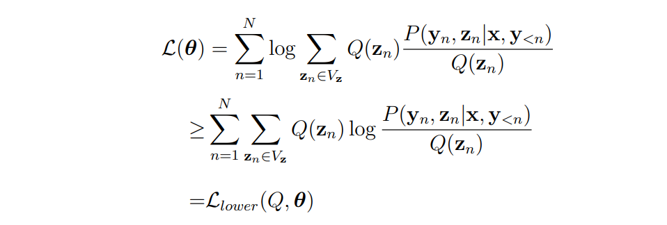

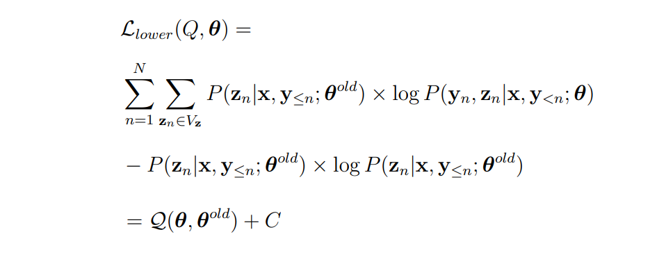

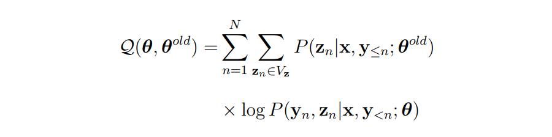

For the EM algorithm we frist compute the posterior distribution with:

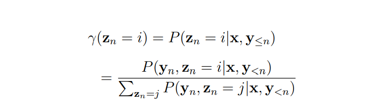

Then the M step can be obtained by :

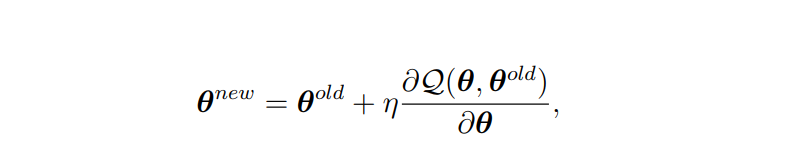

The final objective function can be obtained with:

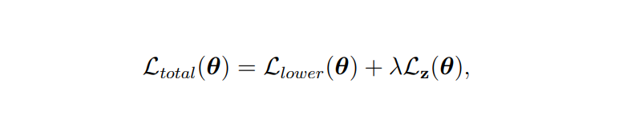

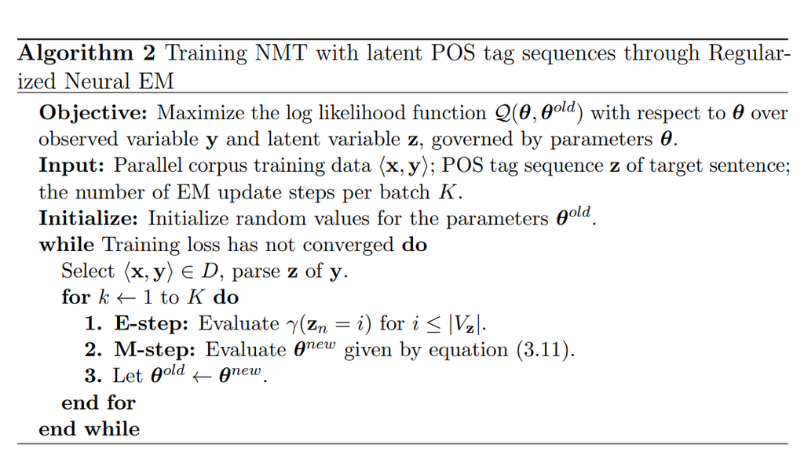

## III. Image Captioning

The decoding probability is modeled using the probability of each target token conditioned on the source input (image and article pair):

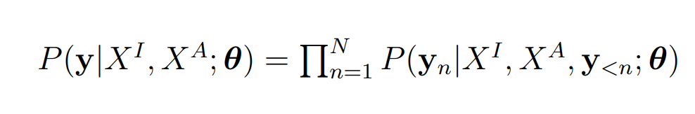

The new decoding probability can be obtained by introducing a new variable for template guidance:

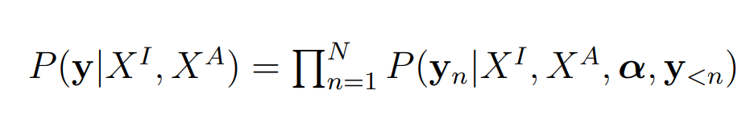

The probability of an entity e appearing in text t can be obtained with:

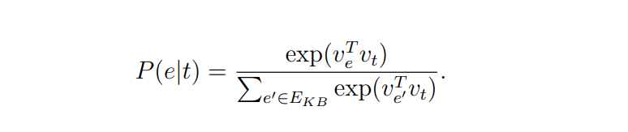

## IV. References

1. Xuewen Yang. Exploring External Knowledge for Accurate modeling of Visual and Language Problems. Arxiv, 2023